# EI-EP06-respuesta-equipo-9-2

2025-12-01

# **Contexto**

Un equipo de investigadores del área de interacción humano-información está estudiando si el área temática y el nivel de dificultad del problema de información influyen en el tiempo (en segundos) que toma un usuario en formular una consulta de búsqueda para resolver dicho problema. Para ello, han reclutado a un grupo de participantes voluntarios, asignados aleatoriamente a distintos grupos. Cada participante debe resolver tres problemas de información con diferentes niveles de dificultad: baja, media y alta. A su vez, cada grupo debe resolver problemas relacionados a una temática diferente. Los datos recolectados contemplan las siguientes variables:

- **id**: identificador único de cada participante.
- **area**: Área temática de los problemas que el participante debe responder. Variable categórica con los niveles Arquitectura, Biología, Computación, Economía, Física, Leyes, Literatura, Matemáticas, Música, Pedagogía, Psicología, Química.
- **dificultad**: Nivel de dificultad del problema resuelto. Variable categórica con los niveles Baja, Media y Alta.
- **tiempo**: Tiempo, en segundos, que toma al participante formular la consulta.

## **Pregunta**

En este momento, los investigadores buscan determinar si existen diferencias en el tiempo que tardan los usuarios en formular consultas para problemas con diferente nivel de dificultad en el área de Arquitectura.

### **Carga de librerías**

```r
library(dplyr)
library(ez)
library(ggpubr)
```

### **Lectura de datos**

Obtengamos la muestra de datos (desde el archivo disponible para el ejercicio práctico anterior) que debemos utilizar.

```r
datos <- read.csv("EP06 Datos.csv")
```

### **Selección de datos**

**Seleccionemos datos de interés**, aprovechando de especificar el orden deseado de los niveles del factor (que por defecto, R ordena alfabéticamente).

```r
datos_largos <- datos |>
  dplyr::filter(area == "Arquitectura") |>
  dplyr::select(id, dificultad, tiempo) |>
  droplevels() |>
  dplyr::mutate(
    id = factor(id),
    dificultad = factor(dificultad, levels = c("Baja", "Media", "Alta"))
  )

head(datos_largos)
```

```
##   id dificultad tiempo
## 1  5       Baja     91
## 2  5      Media     96
## 3  5       Alta     87
## 4 15       Baja     94
## 5 15      Media     95
## 6 15       Alta     93
```

### **Validaión del procedimiento**

Ahora, procedemos a **validar la aplicación del procedimiento estadístico para muestras correlacionadas**, y para esto verificaremos las condiciones necesarias:

La **variable dependiente es el tiempo**, el que por naturaleza es continuo y se mide en una escala de intervalos iguales.

Los **conjuntos de datos, constituidos por tríos de observaciones, son independientes entre sí**, dado que cada trío corresponde a una persona diferente seleccionada mediante un proceso aleatorio.

Una vez confirmadas estas condiciones, tambien se debe **evaluar la normalidad de la distribución de la variable tiempo dentro de cada grupo**, para determinar si usaremos métodos paramétricos o si debemos optar por alternativas no paramétricas.

```r
#Test de shapiro para cada uno de los países de la lista
tests_normalidad <- by(datos_largos[["tiempo"]],
                       datos_largos[["dificultad"]],
                       shapiro.test)
print(tests_normalidad)
```

```
## datos_largos[["dificultad"]]: Baja
##
##  Shapiro-Wilk normality test
##
## data:  dd[x, ]
## W = 0.98451, p-value = 0.02696
##
## ------------------------------------------------------------
## datos_largos[["dificultad"]]: Media
##
##  Shapiro-Wilk normality test
##
## data:  dd[x, ]
## W = 0.98794, p-value = 0.08824
##
## ------------------------------------------------------------
## datos_largos[["dificultad"]]: Alta
##
##  Shapiro-Wilk normality test
##
## data:  dd[x, ]
## W = 0.99309, p-value = 0.4724
```

La **condición de esfericidad** se verificará posteriormente.

### **ANOVA**

De esta forma, se aplicará ANOVA para muestras correlacionadas considerando una significación de 0,05.

```r
alfa <- 0.05

omnibus <- ezANOVA(data = datos_largos, dv = tiempo, within = dificultad, wid = id, return_aov = TRUE)
cat("Resumen Anova:\n")
```

```
## Resumen Anova:
```

```r
print(summary(omnibus[["aov"]]))
```

```
##
## Error: id
##            Df Sum Sq Mean Sq F value Pr(>F)
## Residuals 199  13043   65.54
##
## Error: id:dificultad
##             Df Sum Sq Mean Sq F value Pr(>F)
## dificultad   2   9228    4614   88.64 <2e-16 ***
## Residuals  398  20718      52
## ---
## Signif. codes:  0 '***' 0.001 '**' 0.01 '*' 0.05 '.' 0.1 ' ' 1
```

```r
cat("Resultado de la prueba de Mauchly:\n\n")
```

```
## Resultado de la prueba de Mauchly:
```

```r
print(omnibus[2])
```

```
## $`Mauchly's Test for Sphericity`
##       Effect         W         p p<.05
## 2 dificultad 0.9936533 0.5324159
```

```r
cat("Resultado de la prueba ANOVA:\n\n")
```

```
## Resultado de la prueba ANOVA:
```

```r
print(omnibus[1])
```

```
## $ANOVA
##       Effect DFn DFd        F            p p<.05       ges
## 2 dificultad   2 398 88.63502 1.452953e-32     * 0.2146551
```

Segun los resultados de la prueba de **esfericidad de Mauchly** (W=0.9936533;p=0.5324159), **se falla en rechazar hipótesis nula de esta prueba**, por lo que podemos decir que no existe suficiente evidencia estadística para descartar que se cumple la condición de esfericidad en estos datos.

Interpretemos este resultado ómnibus. Dado que p<0.05 **se rechaza con un 95% de confianza la hipotesis nula de que no existen diferencias significativas entre los tiempos de los distintos tiempos de ejecución.** En otras palabras, esto quiere decir que si existen diferencias en el tiempo que requieren las personas para un problema de información en el area de la Arquitectura con distintos niveles de dificultad.

### **Procedimiento post-hoc**

Debido a que el procedimiento anterior de tipo omnibus encuentra diferencias estadísticamente significativas, **es necesario realizar un procedimiento post-hoc.** Para esto, usaremos el procedimiento **post-hoc de Holm:**

```r
prueba_holm <- pairwise.t.test(datos_largos[["tiempo"]], datos_largos[["dificultad"]], p.adj = "holm", paired = TRUE, conf.level = 1- alfa)
prueba_holm
```

```
##
##  Pairwise comparisons using paired t tests
##
## data:  datos_largos[["tiempo"]] and datos_largos[["dificultad"]]
##
##       Baja    Media
## Media 1.2e-07 -
## Alta  2.5e-13 < 2e-16
##
## P value adjustment method: holm
```

Este análisis post-hoc previamente aplicado revela diferencias estadísticamente significativas entre todos los niveles de dificultad. Se observa que el tiempo de ejecución varía en **Baja v/s Alta, asi como tambien en Baja v/s Media y Media v/s Alta**, lo que sugiere que cada incremento en el nivel de dificultad conlleva un cambio perceptible en el desempeño de los participantes, ya sea positivo o negativo, y que dificilmente podría ser debido al azar. Podemos aplicar un **grafico del tamaño del efecto** para visualizar un poco mejor estos resultados:

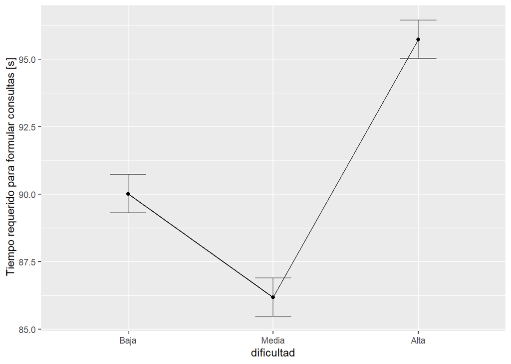

```r
g_efecto <- ezPlot(data = datos_largos, x = dificultad,
                   dv = tiempo, within = dificultad, wid = id,
                   y_lab = " Tiempo requerido para formular consultas [s]"
)
print(g_efecto)
```

### **Conclusión final**

El **análisis post-hoc mediante pruebas t pareadas con corrección de Holm** indica que en el área de la Arquitectura el nivel de dificultad influye significativamente en el tiempo requerido para formular consultas.

Los resultados **muestran diferencias estadísticamente significativas** entre todos los niveles. Al comparar la dificultad Baja con la Media, se observa una reducción significativa del tiempo ($p = 1.2e-07$), lo que indica un mejor desempeño en la dificultad intermedia. Sin embargo esto cambia drásticamente al comparar la dificultad Alta con la Media y la Baja, donde el p-value es prácticamente cero ($p < 2e-16$ y $p = 2.5e-13$ respectivamente).